# Métodos Computacionais II

2018/1

[Jony Arrais Pinto Junior](http://lattes.cnpq.br/4940428746026448)

## 1 - Conteúdo Aula 09

- Gráficos;
- Exercícios.

## 2 - Gráficos

### 2.1 - Gráfico de uma distribuição de probabilidade

Seja $X \sim Exp(0.5)$. Se quisermos desenhar a função de densidade de probabilidade e função de distribuição acumulada de $X$ para os valores de 0 a 15, basta usarmos os seguintes comandos:

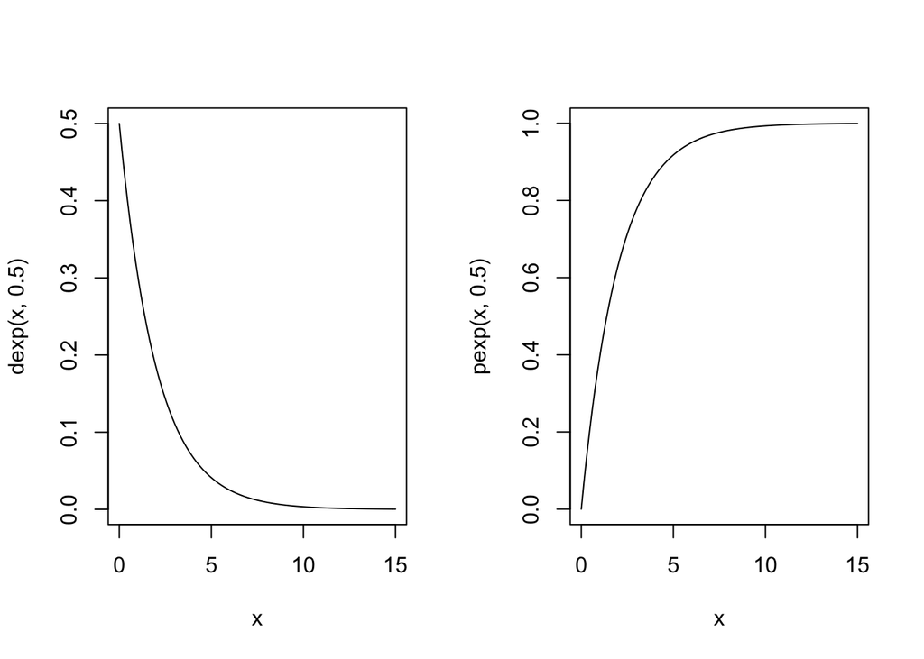

```r
par(mfrow = c(1,2))
curve(dexp(x,0.5),0,15)
curve(pexp(x,0.5),0,15)
```

```r
par(mfrow = c(1,1))
```

Como representar graficamente a distribuição de probabilidade de $Y$ e a função de distribuição acumulada de $Y$ para os valores de 0 a 10.

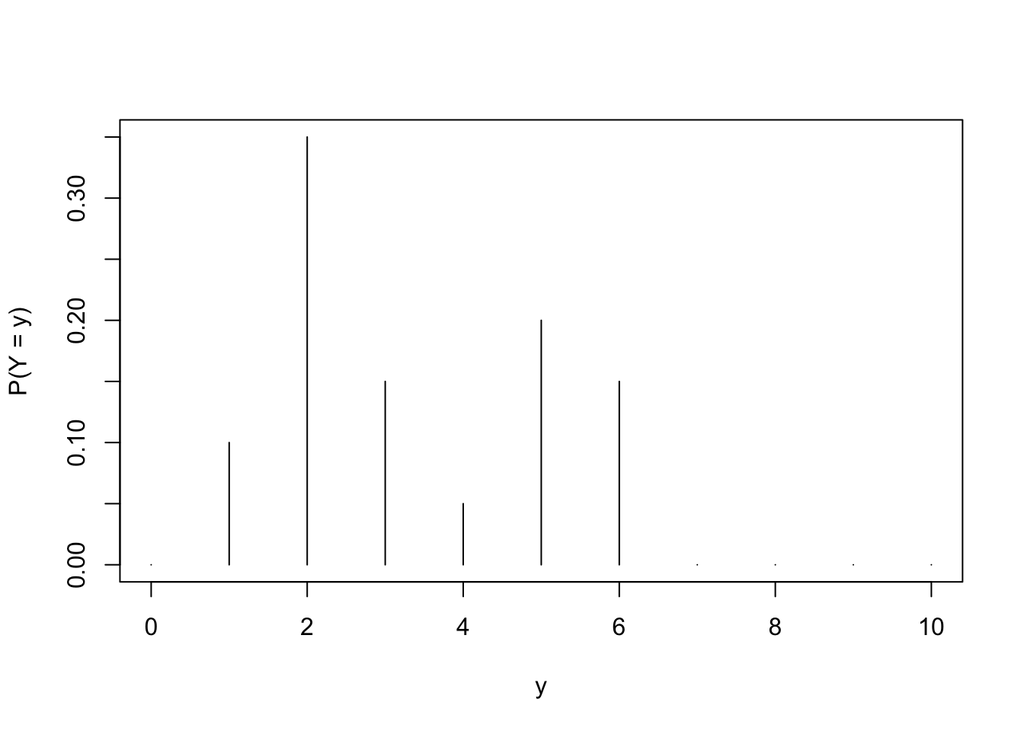

```r
#Definindo os valores de y para os quais queremos representar os gráficos
y = 0:10

#Criando o vetor de probabilidades de y nesses pontos
prob.y = c(0,0.1,0.35,0.15,0.05,0.2,0.15,0,0,0,0)

#Criando o vetor de probabilidades acumulada de y nesses pontos
acum.y = c(0,0.1,0.45,0.6,0.65,0.85,1,1,1,1,1)

#Plotando o gráfico da distribuição de probabilidade de Y
plot(y,prob.y,type="h",ylab="P(Y = y)")
```

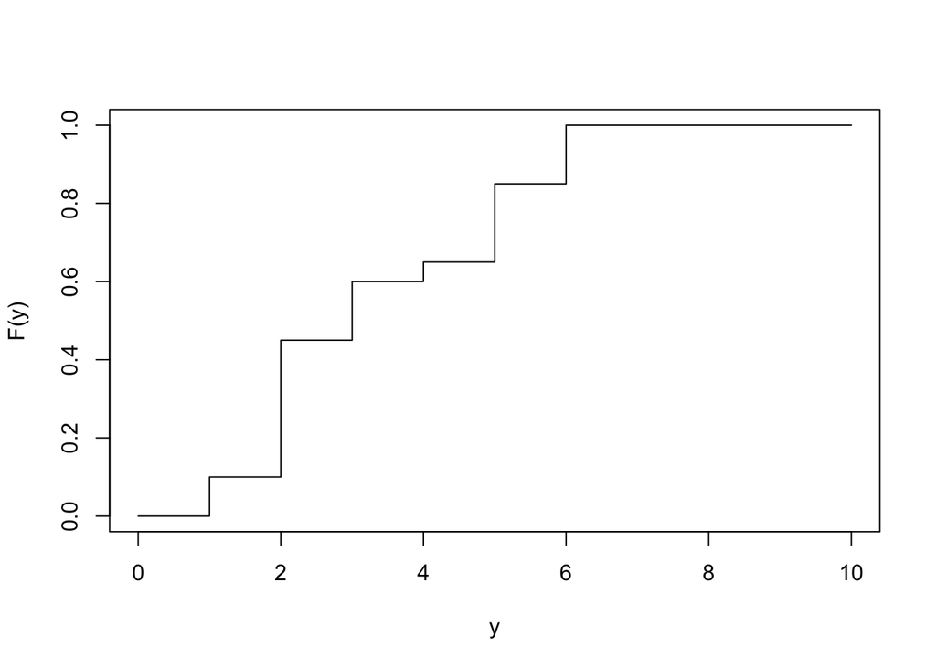

```r
#Plotando o gráfico da distribuição acumulada de y
plot(y,acum.y,type="s",ylab="F(y)")
```

### 2.2 - QQ-plot

O qq-plot é um gráfico dos dados ordenados contra os quantis esperados de uma certa distribuição.

Quanto mais próximo os pontos estiverem da bissetriz do primeiro quadrante mais próximo os dados observados estão da distribuição considerada.

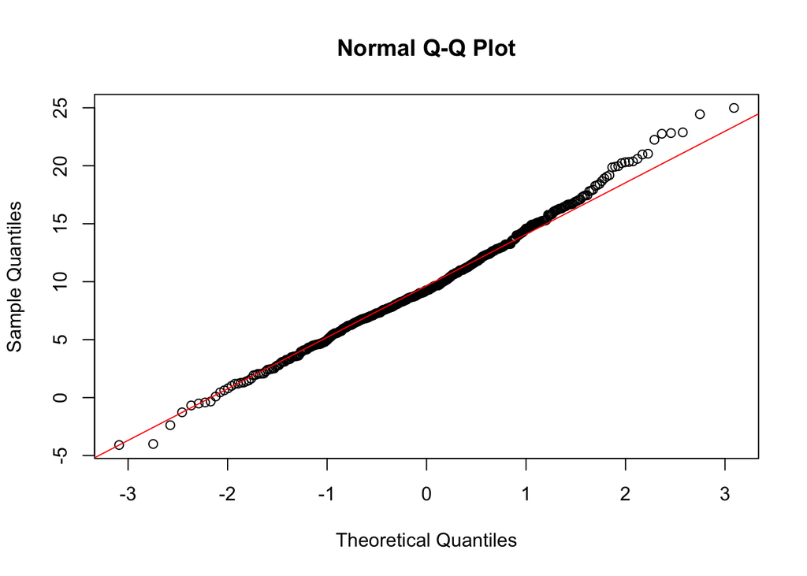

```r
#O caso de uma Normal
amostra = rnorm(500,10,5)
qqnorm(amostra)
qqline(amostra, col="red")
```

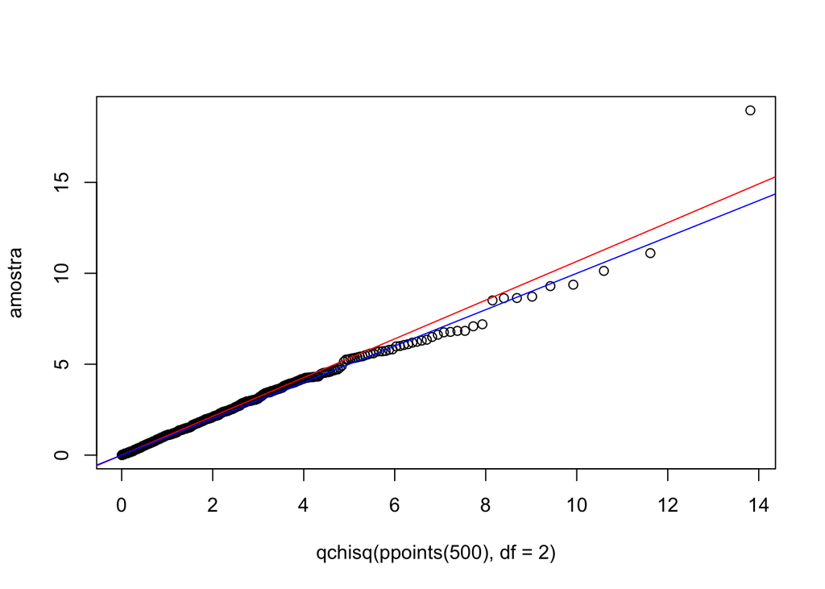

```r
#O caso de uma qui-quadrado
amostra = rchisq(500, df = 2)
qqplot(qchisq(ppoints(500),df=2),amostra)
qqline(amostra,distribution=function(p) qchisq(p, df = 2),probs=c(0.25,0.75),col="red")
abline(coef=c(0,1),col="blue")
```

## 3 - Exercícios

- 1. Represente graficamente a função de distribuição de probabilidade e a função de distribuição acumulada de uma $Y \sim Binomial(10,0.3)$
- 2. Seja x=c(1.17679492779598, 4.12808481898142, 6.84009639342599, 4.62396499367723, 4.63064125068094, 0.697736805369257, -1.54689731857685, 2.6226214139017, -3.68886057293359, 0.156209160612289, -0.117690301382911, 11.9423015290236, 5.35958304821179, 10.1505934589472, 0.546363508798315, 5.79577214757444, 1.70965081306342, 2.17740416621832, 5.77147638386793, 1.50004367164048, 1.06830827899683, 14.0882967261283, -2.14582913064989, 7.57040119578058, 6.20587365022727, 6.00406258764283, 2.29196931870061, 1.0850636553045, 5.33834929108081, 7.08745262367218, 1.122504201815, 7.80120723450541, -2.80700563260022, 6.22249517673939, 1.85236639555357, 7.14612911837738, -0.236964459352484, 3.68052949935412, 1.35674555572705, 6.58847860462386, 4.22740902860253, 0.430627410370857, 5.19607826394638, 7.06981972105624, 7.00423765233855, -0.332492429634505, 2.84185100002307, -1.57925017753043, 5.76841111986168, 5.52402905088285, -1.84433762953897, -4.19234025774712, 0.624342752574144, 1.9175159915615, 9.90911766561835, 8.47745969322409, 10.6280557393687, 6.53070377837361, -1.27993149153713, 3.94001655735459, 1.69345923296295, 7.47004534863078, -1.28218918040618, 0.282905828268042, 3.56649842815371, 5.57902834536132, 7.1466984860609, 4.23928058971672, 0.0969372886880002, 5.98832661687155, 3.1928766735707, 8.82034692554731, 4.08400344418257, 0.374975823974534, -1.39602066894785, 4.27299336403442, 4.02470096537124, 11.9393969128457, 4.14033081814569, 13.2894407048086, -0.261208210940003, 9.46633441309086, 8.50232574205073, 3.44635072290866, -0.303214760449643, 6.54592270018141, 3.85240670711338, 3.487978741507, -3.08897694105349, 3.16529926759855, 12.723505163494, 1.82293691229578, -3.34618400247682, -6.24292192874858, 3.58564131138742, 9.34917949755516, 8.77307220443257, 2.95857551832172, 2.67770156193795, -4.54410994392327 ). Você diria que $x$ é proveniente de uma distribuição Normal ou de uma distribuição t com 5 gruas de liberdade?